# Дисперсионный анализ (ANOVA)

Литвинцев И.С

## Одномерный однофакторный дисперсионный анализ

### 1. Подготовка данных

```r
data <- read.table("C:/Users/806263/Desktop/SPbU/Магистратура Матмех (2017-2019)/Применение статистических методов к реальным данным/Данные/cities (данные по американским городам).txt", dec = ",")
```

В качестве группирующего признака выберем штат (*STATE*), а в качестве переменной-отклика процент афроамериканцев (*BLACK.*) в различных городах США

Проверим гипотезу о том, что в среднем процент афроамериканцев в различных штатах одинаков. Альтернативная гипотеза заключается в том, что найдется хотя бы один штат, среднее значение в котором отлично от остальных.
$$H_0: \mu_1 = \dots = \mu_r$$
$$H_1:\mu_1 \neq \dots \neq \mu_r$$
Определим сколько всего имеется групп и элементов в них:

```r
state_summary <- summary(data$STATE); sort(state_summary)
```

```
## AK DC GA HI IL IN KS MA MD MI NE NM NV OR WA WI AL KY LA MN MO NC NJ OK PA
##  1  1  1  1  1  1  1  1  1  1  1  1  1  1  1  1  2  2  2  2  2  2  2  2  2
## TN AZ CO NY VA FL OH TX CA
##  2  3  3  3  3  4  5  8 12
```

Для анализа выберем 3 наибольшие группы (т.к. число элементов в остальных группах слишком мало). Это Техас (TX), Огайо (OH) и Калифорния (CA).

```r
california <- data[data$STATE == "CA" , c("STATE", "BLACK.")]
texas <- data[data$STATE == "TX" , c("STATE", "BLACK.")]
ohio <- data[data$STATE == "OH" , c("STATE", "BLACK.")]

states <- rbind(california, ohio, texas)

states <-  data.frame(STATE = as.character(states$STATE), BLACK. = states$BLACK.) # приходится создавать новый дата фрейм, чтобы количество уровней фактора STATE стало равно трем
n <- length(states$STATE); n
```

```
## [1] 25
```

```r
r <- length(unique(states$STATE)); r
```

```
## [1] 3
```

```r
n_i <- tapply(X = states$BLACK., INDEX = states$STATE, FUN = length); n_i # число элементов в каждой группе
```

```
## CA OH TX
## 12  5  8
```

### 2. Модель одномерного однофакторного дисперсионного анализа с фиксированными эффектами

$$x_{ij} = \mu + \alpha_i + \varepsilon_{ij}, \quad i \in 1:r, \: j \in 1:n_i$$
Где ошибки $\varepsilon_{ij} \sim N(0,\sigma^2)$ и независимы, $\alpha_i$ – главные эффекты, $\mu$ – генеральное среднее. Найдем оценки параметров $\mu$ и $\alpha_i$
$$\hat{\mu} = \bar{x}=\frac{1}{n}\sum_{i=1}^{r} \sum_{j=1}^{n_i} x_{ij} , \qquad \hat{\alpha_i} = \bar{x}_{i*} -\bar{x} = \frac{1}{n_i}\sum_{j=1}^{n_i} x_{ij} - \bar{x}$$

```r
x_mean <-  mean(states$BLACK.); x_mean
```

```
## [1] 16.368
```

```r
xi_mean <- tapply(X = states$BLACK., INDEX = states$STATE, FUN = mean); xi_mean
```

```
##       CA       OH       TX
## 11.85833 30.26000 14.45000
```

```r
alpha <- xi_mean - x_mean; alpha
```

```
##        CA        OH        TX
## -4.509667 13.892000 -1.918000
```

Далеее требуется удостовериться, что данные в каждой группе подчиняются нормальному закону распределения. Для этого, в рамках истинности нулевой гипотезы, построим гистограмму ошибок модели и проведем тест Шапиро-Уилка.

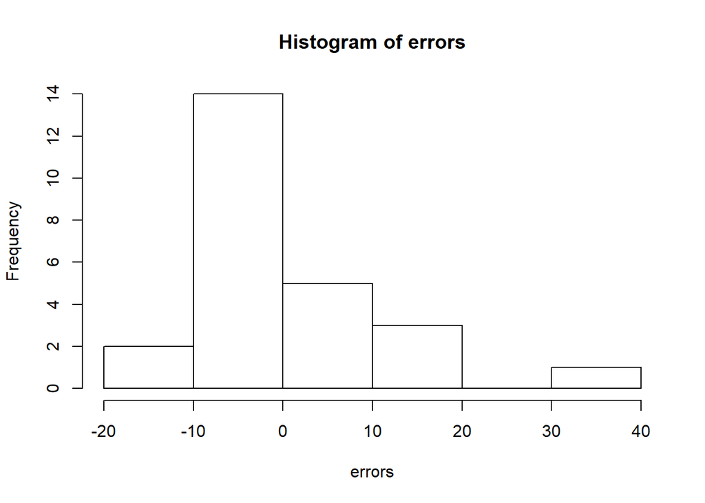

```r
california_eps <- california$BLACK. - xi_mean["CA"]
texas_eps <- texas$BLACK. - xi_mean["TX"]
ohio_eps <- ohio$BLACK. - xi_mean["OH"]
errors <- c(california_eps, texas_eps, ohio_eps)
hist(errors)
```

```r
shapiro.test(errors)
```

```
##
##  Shapiro-Wilk normality test
##
## data:  errors
## W = 0.8595, p-value = 0.002683
```

P-значение теста Шапиро-Уилка достаточно мало. Следовательно, можно сказать, что данные в группах не имеют нормального распределения.

*Вопрос: Можем ли мы продолжать дисперсионный анализ?*

### 3. Построение статистики критерия

Рассчитаем общий источник вариации и разобьем его на сумму внутри и межгрупповой вариаций.
$$SST = Q = \sum_{i=1}^{r}\sum_{j=1}^{n_i}(x_{ij} - \bar{x})^2=\sum_{i=1}^{r}\sum_{j=1}^{n_i}(x_{ij} - \bar{x}_i + \bar{x}_i -\bar{x})^2 = SSB + SSW$$
$$SSB = Q_1 = \sum_{i=1}^{r} n_i(\bar{x}_i - \bar{x})^2, \quad SSW = Q_2 = \sum_{i=1}^{r}\sum_{j=1}^{n_i}(x_{ij} - \bar{x}_i)^2$$

```r
SST <- (states$BLACK. - x_mean)%*%(states$BLACK. - x_mean); SST
```

```
##          [,1]
## [1,] 3864.134
```

```r
SSB <- n_i%*%alpha^2; SSB
```

```
##          [,1]
## [1,] 1238.413
```

```r
SSW <- SST - SSB; SSW # или аналогично SST <- errors%*%errors
```

```
##          [,1]
## [1,] 2625.721
```

Число степеней свободы $SST, SSB$ и $SSW$ $(Q, Q_1$ и $Q_2)$ равно $n-1, r-1$ и $n-r$ соответственно. Построим статистику Фишера:
$$F = \frac{SSB/(r-1)}{SSW/(n-r)}=\frac{Q_1/(r-1)}{Q_2/(n-r)} \sim F(r-1, n-r)$$

```r
F <- (SSB/(r-1))/(SSW/(n-r)); F
```

```
##          [,1]
## [1,] 5.188116
```

Осталось рассчитать p-value и сделать вывод.

```r
p_value <- 1-pf(F, r-1, n-r); p_value
```

```
##            [,1]
## [1,] 0.01426134
```

### 4. Проверка результатов

Воспользовавшись встроенной функцией aov(), убдеимся, что рассчеты верны

```r
a <- aov(BLACK.~STATE, states)
summary(a)
```

```
##             Df Sum Sq Mean Sq F value Pr(>F)
## STATE        2   1238   619.2   5.188 0.0143 *
## Residuals   22   2626   119.4
## ---
## Signif. codes:  0 '***' 0.001 '**' 0.01 '*' 0.05 '.' 0.1 ' ' 1
```